# God Spiked the Integers, and the Punch

Gina Nichols

8/18/2020

# Easy

## E1

logodds = log(p/(1-p))

Lower chance than 50/50 is negative log-odds If p = 0.35, logodds = -0.62

A 50% chance should mean a log-odds of 0 - the chances of the two are the same. If p = 0.5, logodds = 0

Higher than 50/50 is positive logodds If p = 0.75, logodds = 1.1

## E2

If logodds = 3.2, p = 0.96

On some page he talks about this but I can’t find it.

## E3 🆘

I think it means that a unit increase in the predictor vastly increases the probability of the event. Maybe by 0.85%, but I’m not sure.

## E4

Offsets make it possible to have things in different units. Say I measured weeds in a m-2 area, but my undergrad is a true American and she measured them in a ft-2 area. I can still use the data!

# Medium

## M1 🆘

Liklihood is related to entropy. In aggregated form of data, there are more ways to see each ‘observation’, so the entropy is higher, which I think changes what the likelihood looks like.

## M2

One unit increase in the predictor results in an increase of almost 2 orders of magnitude in the response variable.

## M3

It makes it so p is always between 0-1. **But it can never be 1, right? You can’t divide by 0.**

## M4

The exponential of a value is always above 0, and counts are always above 0.

## M5 🆘

Why would you use a logit link for the mean of a Poisson GLM? It means you expect the mean of a count variable to be between 0-1? No, I cannot think of a situation where you’d expect this.

## M6

*Constraints for which the binomial and Poisson have max entropy?*

Binomial - When ’a count outcome *y* for which each observation arises from *n* trials and with a constant expected value *np*.

Poisson - When the mean is equal to the variance. Seems more like a special case of the normal distribution, rather than the binomial distribution. But if you’re in a binomial situation and n is very large, you have a Poisson

## M7

*Create m11.4 using both quap and ulam*

```r
dat_list <-
  list(
    pulled_left = d$pulled_left,
    actor = d$actor,
    trt = as.integer(d$trt) )

m11.4 <- ulam(
  alist(
    pulled_left ~ dbinom(1, p),
    logit(p) <- a[actor] + b[trt],
    a[actor] ~ dnorm(0, 1.5),
    b[trt] ~ dnorm(0, 0.5)
  ), data = dat_list, chains = 4, log_lik = T )
```

```r
m11.4quap <- quap(
  alist(
    pulled_left ~ dbinom(1, p),
    logit(p) <- a[actor] + b[trt],
    a[actor] ~ dnorm(0, 1.5),
    b[trt] ~ dnorm(0, 0.5)
  ), data = d)
```

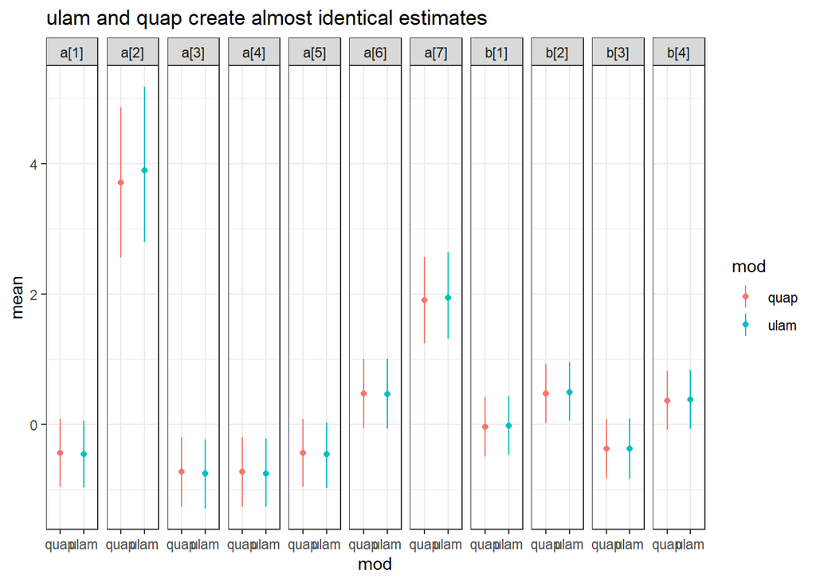

```r
rns <- rownames(precis(m11.4, depth = 2) )

precis(m11.4, depth = 2) %>%
  as.data.frame() %>%
  mutate(mod = "ulam") %>%
  bind_rows(
    precis(m11.4quap, depth = 2) %>%
      as.data.frame() %>%
      mutate(mod = "quap")
  ) %>%
  mutate(xparm = rep(rns, 2)) %>%
  janitor::clean_names() %>%
  ggplot(aes(mod, mean, color = mod)) +
  geom_point() +
  geom_linerange(aes(ymin = x94_5_percent, ymax = x5_5_percent)) +
  facet_grid(.~xparm) +
  labs(title = "ulam and quap create almost identical estimates")
```

They are identical except for **old lefty**. Try using a terrible prior (normal(0, 10) for the actor intercept.

```r
m11.4x <- ulam(
  alist(
    pulled_left ~ dbinom(1, p),
    logit(p) <- a[actor] + b[trt],
    a[actor] ~ dnorm(0, 10),
    b[trt] ~ dnorm(0, 0.5)
  ), data = dat_list, chains = 4, log_lik = T )
```

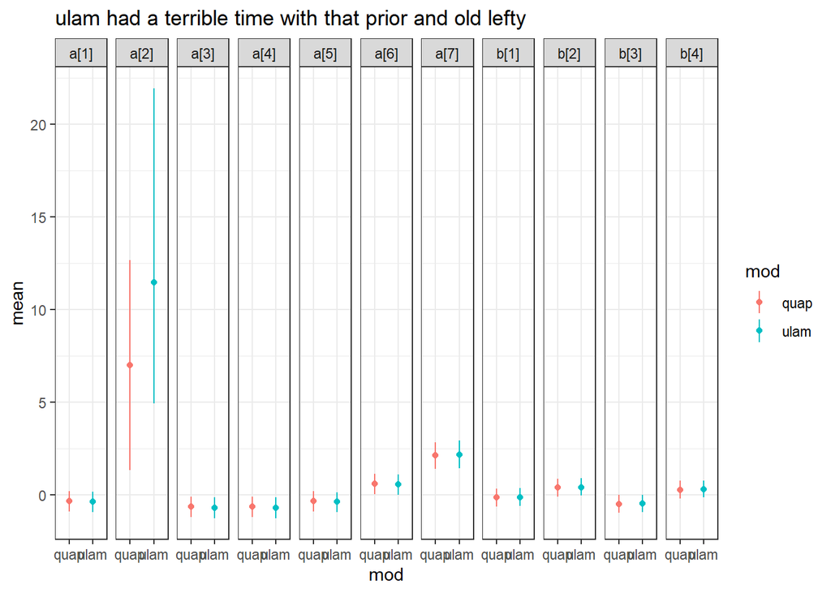

```r
m11.4quapx <- quap(
  alist(
    pulled_left ~ dbinom(1, p),
    logit(p) <- a[actor] + b[trt],
    a[actor] ~ dnorm(0, 10),
    b[trt] ~ dnorm(0, 0.5)
  ), data = d)

rns <- rownames(precis(m11.4x, depth = 2) )

precis(m11.4x, depth = 2) %>%
  as.data.frame() %>%
  mutate(mod = "ulam") %>%
  bind_rows(
    precis(m11.4quapx, depth = 2) %>%
      as.data.frame() %>%
      mutate(mod = "quap")
  ) %>%
  mutate(xparm = rep(rns, 2)) %>%
  janitor::clean_names() %>%
  ggplot(aes(mod, mean, color = mod)) +
  geom_point() +
  geom_linerange(aes(ymin = x94_5_percent, ymax = x5_5_percent)) +
  facet_grid(.~xparm) +
  labs(title = "ulam had a terrible time with that prior and old lefty")
```

Why does MCMC have a harder time? It goes wandering, I guess.

# M8

Use the Kline data but drop Hawaii.

```r
data(Kline)
d2 <- Kline %>%
  mutate(P = scale(log(population)),
         contact_id = ifelse(contact == "high", 2, 1))

dat2 <- list(
  T = d2$total_tools,
  P = d2$P,
  cid = d2$contact_id
)

m11.10 <- ulam(
  alist(
    T ~ dpois( lambda ),
    log(lambda) <- a[cid] + b[cid]*P,
    a[cid] ~ dnorm( 3, 0.5 ),
    b[cid] ~ dnorm( 0, 0.2 )
  ), data = dat2, chains = 4, log_lik = TRUE )
```

```r
d2out <- Kline %>%
  mutate(P = scale(log(population)),
         contact_id = ifelse(contact == "high", 2, 1)) %>%
  filter(culture != "Hawaii")

dat2out <- list(
  T = d2out$total_tools,
  P = d2out$P,
  cid = d2out$contact_id
)

m11.10out <- ulam(
  alist(
    T ~ dpois( lambda ),
    log(lambda) <- a[cid] + b[cid]*P,
    a[cid] ~ dnorm( 3, 0.5 ),
    b[cid] ~ dnorm( 0, 0.2 )
  ), data = dat2out, chains = 4, log_lik = TRUE )
```

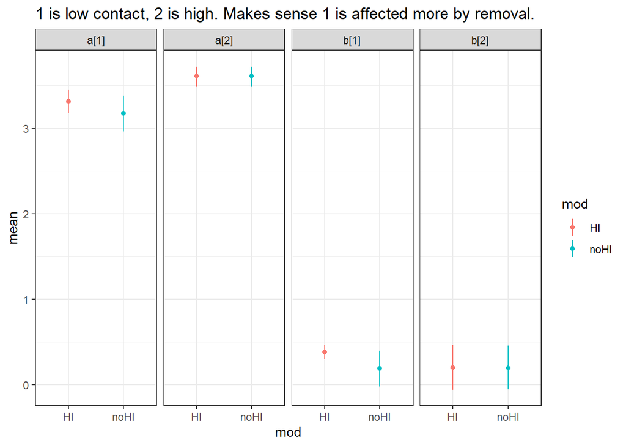

```r
rns2 <- rownames(precis(m11.10, depth = 2) )
rns3 <- rownames(precis(m11.10out, depth = 2) )

precis(m11.10, depth = 2) %>%
  as.data.frame() %>%
  mutate(mod = "HI") %>%
  bind_rows(
    precis(m11.10out, depth = 2) %>%
      as.data.frame() %>%
      mutate(mod = "noHI")
  ) %>%
  mutate(xparm = c(rns2, rns3)) %>%
  janitor::clean_names() %>%
  ggplot(aes(mod, mean, color = mod)) +
  geom_point() +
  geom_linerange(aes(ymin = x94_5_percent, ymax = x5_5_percent)) +
  facet_grid(.~xparm) +
  labs(title = "1 is low contact, 2 is high. Makes sense 1 is affected more by removal.")
```

# Hard

## H4

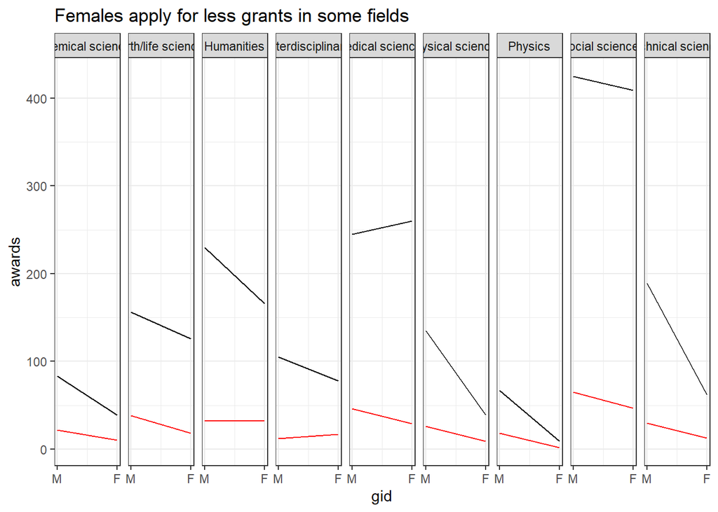

```r
data("NWOGrants")
gr <-
  NWOGrants %>%
  mutate(gid = ifelse(gender == "m", 1, 2),
         deptid = as.numeric(as.factor(discipline)))

gr %>%
  ggplot(aes(gid, awards)) +
  geom_line(color = "red") +
  geom_line(aes(y = applications), color = "black") +
  scale_x_continuous(breaks = c(1, 2), labels = c("M", "F")) +
  facet_grid(.~discipline) +
  labs(title = "Females apply for less grants in some fields")
```

```r
mh4 <- quap(
  alist(
    awards ~ dbinom( applications, p ),
    logit(p) <- a[gid],
    a[gid] ~ dnorm(0, 1.5)
  ), data = gr )

precis(mh4, depth = 2)
```

```
##           mean         sd      5.5%     94.5%
## a[1] -1.531418 0.06462435 -1.634700 -1.428136
## a[2] -1.737428 0.08121368 -1.867224 -1.607633
```

Look at differences on scale that makes sense

```r
post <- extract.samples(mh4)
diff_a <- post$a[,1] - post$a[,2]
diff_p <- inv_logit(post$a[,1]) - inv_logit(post$a[,2])
precis(list (diff_a = diff_a, diff_p= diff_p))
```

```
##              mean         sd        5.5%      94.5%
## diff_a 0.20769743 0.10356275 0.043557269 0.37107234
## diff_p 0.02827571 0.01399733 0.006022925 0.05033544
##                                                                                       histogram
## diff_a                         ▁▁▂▇▇▃▁▁
## diff_p ▁▁▁▂▅▇▇▃▁▁▁
```

Men are 1-5% more likely to be funded.

But what if we ask if it’s different within fields?

```r
mh4b <- quap(
  alist(
    awards ~ dbinom( applications, p ),
    logit(p) <- a[gid] + delta[deptid],
    a[gid] ~ dnorm(0, 1.5),
    delta[deptid] ~ dnorm(0, 1.5)
  ), data = gr )

precis(mh4b, depth = 2)
```

```
##                mean        sd       5.5%      94.5%
## a[1]     -1.1580442 0.4565098 -1.8876350 -0.4284533
## a[2]     -1.2956883 0.4597880 -2.0305183 -0.5608583
## delta[1]  0.1638564 0.4908975 -0.6206925  0.9484054
## delta[2] -0.1753471 0.4742535 -0.9332959  0.5826016
## delta[3] -0.4101788 0.4709093 -1.1627828  0.3424253
## delta[4] -0.4463883 0.4895114 -1.2287221  0.3359455
## delta[5] -0.5154495 0.4687248 -1.2645623  0.2336632
## delta[6] -0.1882008 0.4856751 -0.9644034  0.5880019
## delta[7]  0.1399928 0.5114936 -0.6774727  0.9574584
## delta[8] -0.6368021 0.4640407 -1.3784288  0.1048245
## delta[9] -0.3807523 0.4792314 -1.1466566  0.3851520
```

```r
post <- extract.samples(mh4b)
diff_a <- post$a[,1] - post$a[,2]
diff_p <- inv_logit(post$a[,1]) - inv_logit(post$a[,2])
precis(list (diff_a = diff_a, diff_p= diff_p))
```

```
##              mean         sd         5.5%      94.5%
## diff_a 0.13772596 0.10813663 -0.034988386 0.30986394
## diff_p 0.02369773 0.01979821 -0.006103329 0.05711511
##                                                                                       histogram
## diff_a         ▁▁▁▂▅▇▃▁▁▁
## diff_p ▁▁▁▂▇▇▃▁▁▁▁
```

Look at things sorted by overall applications

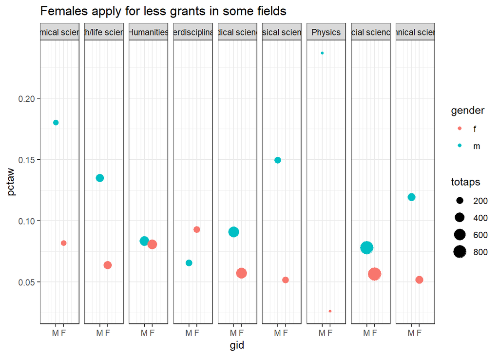

```r
gr %>%
  group_by(discipline) %>%
  mutate(totaps = sum(applications),
         pctaw = awards/totaps) %>%
  arrange(totaps) %>%
  ggplot(aes(gid, pctaw)) +
  geom_point(aes(size = totaps, color = gender)) +
  scale_x_continuous(breaks = c(1, 2), labels = c("M", "F"), expand = c(1, 1)) +
  facet_grid(.~discipline) +
  labs(title = "Females apply for less grants in some fields")
```

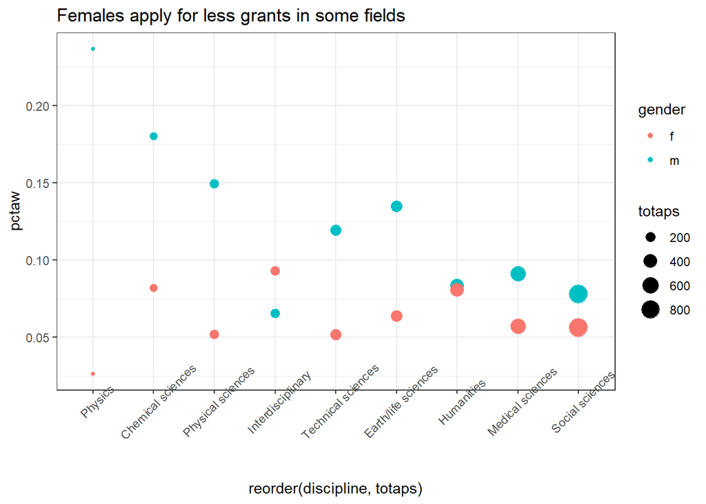

```r
gr %>%
  group_by(discipline) %>%
  mutate(totaps = sum(applications),
         pctaw = awards/totaps) %>%
  arrange(totaps) %>%
  ggplot(aes(reorder(discipline, totaps), pctaw)) +
  geom_point(aes(size = totaps, color = gender)) +
  #scale_x_continuous(breaks = c(1, 2), labels = c("M", "F"), expand = c(1, 1)) +
#  facet_grid(.~discipline) +
  labs(title = "Females apply for less grants in some fields") +
  theme(axis.text.x = element_text(angle = 45))
```